# Feature Engineering (FE) & EDA Assignment 3

Shiyu Hua

Load the dataset

```python
import pandas as pd
path = 'C:/Users/lilyh/Desktop/final semester/5420/assignment3/'
df = pd.read_csv(path + 'XYZloan_default_selected_vars.csv') #, encoding = "ISO-8859-1")
df.head()
```

|  | Unnamed: 0.1 | Unnamed: 0 | id | loan_default | AP001 | AP002 | AP003 | AP004 | AP005 | AP006 | ... | CD162 | CD164 | CD166 | CD167 | CD169 | CD170 | CD172 | CD173 | MB005 | MB007 |
| --- | --- | --- | --- | --- | --- | --- | --- | --- | --- | --- | --- | --- | --- | --- | --- | --- | --- | --- | --- | --- | --- |
| 0 | 0 | 1 | 1 | 1 | 31 | 2 | 1 | 12 | 2017/7/6 10:21 | ios | ... | 13.0 | 13.0 | 0.0 | 0.0 | 1449.0 | 1449.0 | 2249.0 | 2249.0 | 7.0 | IPHONE7 |
| 1 | 1 | 2 | 2 | 0 | 27 | 1 | 1 | 12 | 2017/4/6 12:51 | h5 | ... | -99.0 | -99.0 | -99.0 | -99.0 | -99.0 | -99.0 | -99.0 | -99.0 | NaN | WEB |
| 2 | 2 | 3 | 3 | 0 | 33 | 1 | 4 | 12 | 2017/7/1 14:11 | h5 | ... | 3.0 | 2.0 | 33.0 | 0.0 | 33.0 | 0.0 | 143.0 | 110.0 | 8.0 | WEB |
| 3 | 3 | 4 | 4 | 0 | 34 | 2 | 4 | 12 | 2017/7/7 10:10 | android | ... | 0.0 | 0.0 | 0.0 | 0.0 | 0.0 | 0.0 | 0.0 | 0.0 | 10.0 | OPPO |
| 4 | 4 | 5 | 5 | 0 | 47 | 2 | 1 | 12 | 2017/7/6 14:37 | h5 | ... | -99.0 | -99.0 | -99.0 | -99.0 | -99.0 | -99.0 | -99.0 | -99.0 | NaN | WEB |

5 rows × 89 columns

```python
# check dimensions of the dataset, we found it has 80000 rows and 89 columns
print(df.shape)
print(df.columns) # check column names
df.describe() # Get the Simple Summary Statistics
```

```
(80000, 89)
Index(['Unnamed: 0.1', 'Unnamed: 0', 'id', 'loan_default', 'AP001', 'AP002',
       'AP003', 'AP004', 'AP005', 'AP006', 'AP007', 'AP008', 'AP009', 'TD001',
       'TD002', 'TD005', 'TD006', 'TD009', 'TD010', 'TD013', 'TD014', 'TD015',
       'TD022', 'TD023', 'TD024', 'TD025', 'TD026', 'TD027', 'TD028', 'TD029',
       'TD044', 'TD048', 'TD051', 'TD054', 'TD055', 'TD061', 'TD062', 'CR004',
       'CR005', 'CR009', 'CR012', 'CR015', 'CR017', 'CR018', 'CR019', 'PA022',
       'PA023', 'PA028', 'PA029', 'PA030', 'PA031', 'CD008', 'CD018', 'CD071',
       'CD072', 'CD088', 'CD100', 'CD101', 'CD106', 'CD107', 'CD108', 'CD113',
       'CD114', 'CD115', 'CD117', 'CD118', 'CD120', 'CD121', 'CD123', 'CD130',
       'CD131', 'CD132', 'CD133', 'CD135', 'CD136', 'CD137', 'CD152', 'CD153',
       'CD160', 'CD162', 'CD164', 'CD166', 'CD167', 'CD169', 'CD170', 'CD172',
       'CD173', 'MB005', 'MB007'],
      dtype='object')
```

|  | Unnamed: 0.1 | Unnamed: 0 | id | loan_default | AP001 | AP002 | AP003 | AP004 | AP007 | AP008 | ... | CD160 | CD162 | CD164 | CD166 | CD167 | CD169 | CD170 | CD172 | CD173 | MB005 |
| --- | --- | --- | --- | --- | --- | --- | --- | --- | --- | --- | --- | --- | --- | --- | --- | --- | --- | --- | --- | --- | --- |
| count | 80000.000000 | 80000.000000 | 80000.000000 | 80000.000000 | 80000.000000 | 80000.000000 | 80000.000000 | 80000.000000 | 80000.00000 | 80000.000000 | ... | 79619.000000 | 79619.000000 | 79619.000000 | 79619.000000 | 79619.000000 | 79619.000000 | 79619.00000 | 79619.000000 | 79619.000000 | 77207.000000 |
| mean | 39999.500000 | 40000.500000 | 40000.500000 | 0.193600 | 31.706913 | 1.321813 | 2.014925 | 11.235413 | 3.30130 | 3.117200 | ... | 6.911956 | 14.271694 | 11.773358 | 909.089313 | 810.786219 | 1732.693314 | 1539.33443 | 2513.226491 | 2229.606137 | 5.976272 |
| std | 23094.155105 | 23094.155105 | 23094.155105 | 0.395121 | 7.075070 | 0.467174 | 1.196806 | 2.212313 | 1.33655 | 1.306335 | ... | 28.007499 | 38.235012 | 33.270641 | 1379.553332 | 1245.044602 | 2441.503517 | 2172.71384 | 3404.975112 | 3005.615048 | 3.641814 |
| min | 0.000000 | 1.000000 | 1.000000 | 0.000000 | 20.000000 | 1.000000 | 1.000000 | 3.000000 | 1.00000 | 1.000000 | ... | -99.000000 | -99.000000 | -99.000000 | -99.000000 | -99.000000 | -99.000000 | -99.00000 | -99.000000 | -99.000000 | 0.000000 |
| 25% | 19999.750000 | 20000.750000 | 20000.750000 | 0.000000 | 27.000000 | 1.000000 | 1.000000 | 12.000000 | 2.00000 | 2.000000 | ... | 2.000000 | 5.000000 | 4.000000 | 84.000000 | 34.000000 | 309.000000 | 226.00000 | 539.000000 | 414.000000 | 3.000000 |
| 50% | 39999.500000 | 40000.500000 | 40000.500000 | 0.000000 | 30.000000 | 1.000000 | 1.000000 | 12.000000 | 3.00000 | 3.000000 | ... | 7.000000 | 12.000000 | 10.000000 | 475.000000 | 397.000000 | 1023.000000 | 870.00000 | 1553.000000 | 1324.000000 | 5.000000 |
| 75% | 59999.250000 | 60000.250000 | 60000.250000 | 0.000000 | 35.000000 | 2.000000 | 3.000000 | 12.000000 | 5.00000 | 4.000000 | ... | 14.000000 | 23.000000 | 20.000000 | 1209.000000 | 1080.000000 | 2287.000000 | 2030.00000 | 3296.000000 | 2936.000000 | 8.000000 |
| max | 79999.000000 | 80000.000000 | 80000.000000 | 1.000000 | 56.000000 | 2.000000 | 6.000000 | 12.000000 | 5.00000 | 5.000000 | ... | 1061.000000 | 2792.000000 | 1579.000000 | 48585.000000 | 29664.000000 | 88364.000000 | 54651.00000 | 125352.000000 | 87312.000000 | 47.000000 |

8 rows × 86 columns

#### Split train data and test data

```python
# split train and test, set test size to 0.3
from sklearn.model_selection import train_test_split
X_train, X_test, Y_train, Y_test = train_test_split(df.drop(columns = ['loan_default']),
                                                    df['loan_default'],
                                                    test_size = 0.3,
                                                    random_state=0) # controls the shuffling and for reproducible output
```

```python
train = pd.merge(X_train, Y_train, left_index = True, right_index = True)
test = pd.merge(X_test, Y_test, left_index = True, right_index =True)
```

## Section 1. EDA

#### Perform on **training data only**

#### Perform for following variables:

- AP001, AP003, AP008
- CR009, CR015, CR019
- PA022, PA023, PA029
- TD001, TD005, TD006, TD009, TD010, TD014

From below, we can see around 80% of the train data is not loan_default, and around 20% of train data is loan_default.

```python
train['loan_default'].value_counts() / len(Y_train)
```

```
0    0.805518
1    0.194482
Name: loan_default, dtype: float64
```

First take a look at the variable: AP001

```python
# compute the frequency of AP001
df_ap001 = train[['AP001','loan_default']].groupby('AP001')['loan_default'].agg(['count','sum']).reset_index()
df_ap001.columns = ['AP001','X_counts','Y_counts']
df_ap001['X_pcnt'] = df_ap001['X_counts'] / sum(df_ap001['X_counts'])
df_ap001['Y_by_X_pcnt'] = df_ap001['Y_counts'] / df_ap001['X_counts']
df_ap001.head()
```

|  | AP001 | X_counts | Y_counts | X_pcnt | Y_by_X_pcnt |
| --- | --- | --- | --- | --- | --- |
| 0 | 20 | 79 | 15 | 0.001411 | 0.189873 |
| 1 | 21 | 418 | 110 | 0.007464 | 0.263158 |
| 2 | 22 | 1124 | 224 | 0.020071 | 0.199288 |
| 3 | 23 | 2066 | 429 | 0.036893 | 0.207648 |
| 4 | 24 | 3015 | 632 | 0.053839 | 0.209619 |

Create a function to show the above dataframe for each variable

```python
def dist_df(var):
    df_var = train[[var,'loan_default']].groupby(var)['loan_default'].agg(['count','sum']).reset_index()
    df_var.columns = [var,'X_counts','Y_counts']
    df_var['X_pcnt'] = df_var['X_counts'] / sum(df_var['X_counts'])
    df_var['Y_by_X_pcnt'] = df_var['Y_counts'] / df_var['X_counts']
    return df_var
```

#### AP

Plot the distribution of each variable and the percentage of default distribution, for variables start with 'AP'

```python
var_list_ap = ['AP001','AP003','AP008']
```

```python
#first check simple statistics
for value in var_list_ap:
    print(train[value].describe())
```

```
count    56000.000000
mean        31.719946
std          7.083476
min         20.000000
25%         27.000000
50%         30.000000
75%         35.000000
max         56.000000
Name: AP001, dtype: float64
count    56000.000000
mean         2.014464
std          1.197525
min          1.000000
25%          1.000000
50%          1.000000
75%          3.000000
max          6.000000
Name: AP003, dtype: float64
count    56000.000000
mean         3.110875
std          1.305471
min          1.000000
25%          2.000000
50%          3.000000
75%          4.000000
max          5.000000
Name: AP008, dtype: float64
```

Create a function to loop through plots

```python
def plot_X_and_Y(var):
    import matplotlib
    import matplotlib.pyplot as plt
    import numpy as np

    ind = dist_df(var)[var].astype(str)
    x_count = dist_df(var)['X_pcnt']
    y_by_x = dist_df(var)['Y_by_X_pcnt']

    fig = plt.figure(figsize=(16,4))
    plt.subplot(121)
    plt.bar(ind, x_count)
    plt.xlabel(var)
    plt.ylabel('X_pcnt')
    plt.xticks(ind, rotation=45)
    plt.title(var + ' Distribution')

    plt.subplot(122)
    plt.plot(ind, y_by_x, color='r')
    plt.xlabel(var)
    plt.ylabel('Y_by_X_pcnt')
    plt.xticks(ind, rotation=45)
    plt.title('Y_by_X_pcnt Distribution')
    plt.show()
```

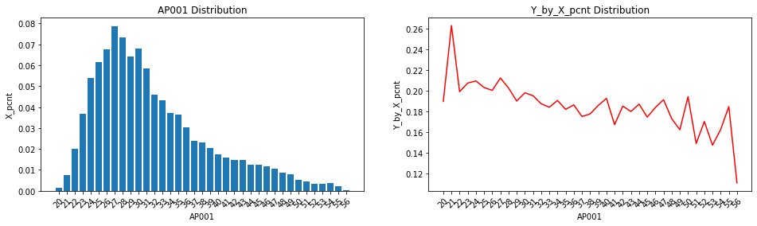

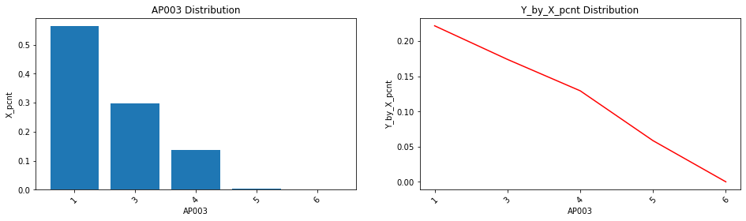

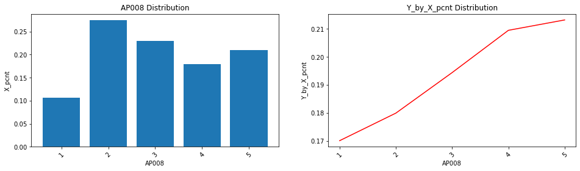

```python
for n in var_list_ap:
    plot_X_and_Y(n)
```

#### Thought process:

```python
import numpy as np
cut_bins = np.quantile(np.array(train['AP001']),np.arange(0,1.1,0.1), axis = 0).tolist()
cut_bins
```

```
[20.0, 24.0, 26.0, 27.0, 28.0, 30.0, 32.0, 34.0, 37.0, 43.0, 56.0]
```

```python
train['AP001_D'] = pd.cut(train['AP001'], bins = [19.9, 24,26,27,28,30,32,34,37,43,99], duplicates = 'drop')
```

```python
train['AP003_D'] = pd.cut(train['AP003'], bins = [0,1,3,7], duplicates = 'drop')
```

Plot again the x_distribution and y_by_x_pcnt with the binned variables

```python
var_list_ap = ['AP001_D','AP003_D','AP008']
```

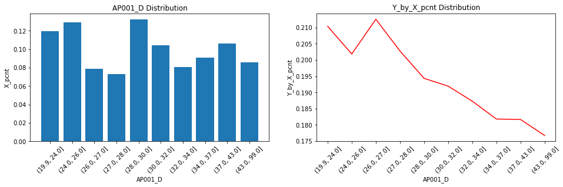

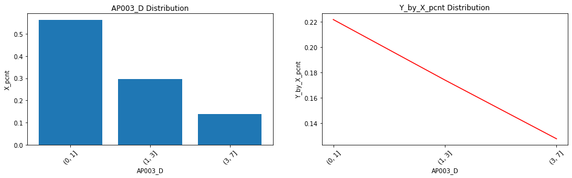

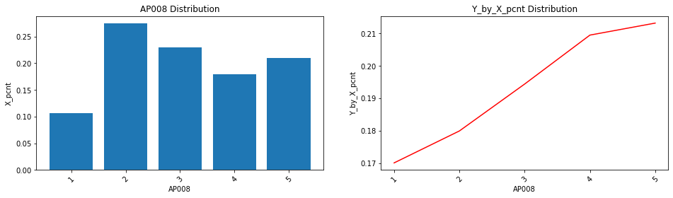

```python
for n in var_list_ap:
    plot_X_and_Y(n)
```

### Conclusion:

- the percentage of default decreases as 'AP001' value increases
- the percentage of default decreases as 'AP003' value increases
- the percentage of default increases as 'AP008' value increases

#### CR

Plot the distribution of each variable and the percentage of default distribution, for variables start with 'CR'

```python
var_list_cr = ['CR009','CR015','CR019']
```

```python
# first check simple statistics
for value in var_list_cr:
    print(train[value].describe())
```

```
count    5.600000e+04
mean     3.509330e+04
std      6.338706e+04
min      0.000000e+00
25%      4.700000e+03
50%      1.723650e+04
75%      4.061600e+04
max      1.420300e+06
Name: CR009, dtype: float64
count    56000.000000
mean         4.925571
std          1.095127
min          2.000000
25%          5.000000
50%          5.000000
75%          6.000000
max          6.000000
Name: CR015, dtype: float64
count    56000.000000
mean         6.194750
std          3.358367
min          1.000000
25%          3.000000
50%          5.000000
75%         10.000000
max         12.000000
Name: CR019, dtype: float64
```

### Thought process:

- Compared to the other two variables, 'CR009' is a continous variable that has a huge range of value. Need to explore the data more before plotting.

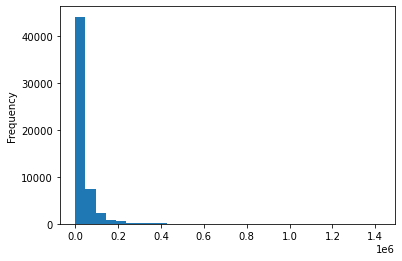

```python
# plot the distribution of CR009 variable
train['CR009'].plot(kind = 'hist', bins = 30)
```

```python
train['CR009'].value_counts() / len(train)
```

```
0        0.165500
5000     0.012929
10000    0.011750
2000     0.008625
20000    0.008125
           ...
18629    0.000018
25716    0.000018
3110     0.000018
30510    0.000018
21456    0.000018
Name: CR009, Length: 19624, dtype: float64
```

```python
import numpy as np
# create bins of 10th percentiles
cut_bins = np.quantile(np.array(train['CR009']),np.arange(0,1.1,0.1), axis = 0).tolist()
cut_bins
```

```
[0.0,
 0.0,
 2499.0,
 6800.0,
 11500.0,
 17236.5,
 24263.600000000006,
 34000.0,
 49982.60000000001,
 82105.39999999992,
 1420300.0]
```

```python
# cut by bins
train['CR009_D'] = pd.cut(train['CR009'], bins = [-1,0,2499,6800,11500,17236,24263,34000,49982,82105,9999999], duplicates='drop')
```

Plot the X_distribution_pcnt and Y_by_X_pcnt for CR009_D and CR015, CR019

```python
var_list_cr = ['CR009_D','CR015','CR019']
```

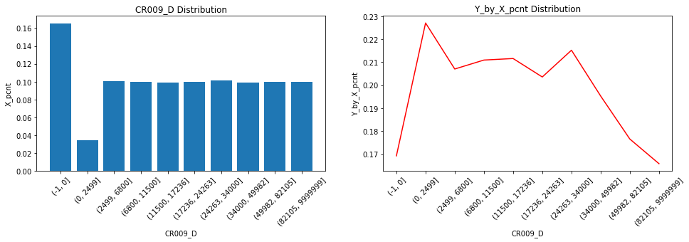

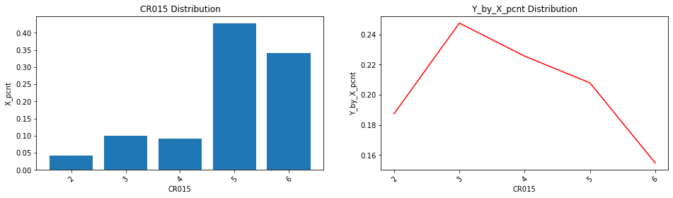

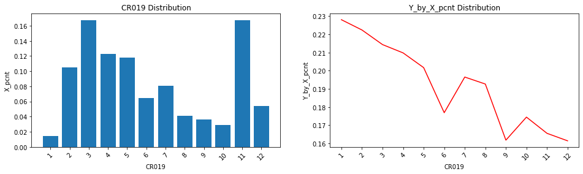

```python
for n in var_list_cr:
    plot_X_and_Y(n)
```

#### PA

Plot the distribution of each variable and the percentage of default distribution, for variables start with 'PA'

```python
var_list_pa = ['PA022', 'PA023', 'PA029']
```

```python
# first check simple statistics
for value in var_list_pa:
    print(train[value].describe())
```

```
count    55742.000000
mean        19.368717
std         39.795114
min        -99.000000
25%         -1.000000
50%         -1.000000
75%         41.000000
max        448.000000
Name: PA022, dtype: float64
count    55742.000000
mean        14.956980
std         37.129082
min        -99.000000
25%         -1.000000
50%         -1.000000
75%         15.000000
max        448.000000
Name: PA023, dtype: float64
count    55742.000000
mean       -42.292705
std         98.078746
min        -99.000000
25%        -98.000000
50%        -98.000000
75%         26.000000
max       2872.000000
Name: PA029, dtype: float64
```

```python
#check missing value
for value in var_list_pa:
    print(train[value].isnull().sum())
```

```
258
258
258
```

### Thought process:

- The range of each continuous variables is large and all variables have missing values.
- Better bin the variables to categorical before plotting

```python
#PA022
cut_bins = np.quantile(np.array(train['PA022'].dropna()),np.arange(0,1.1,0.1), axis = 0).tolist()
cut_bins
```

```
[-99.0, -1.0, -1.0, -1.0, -1.0, -1.0, -1.0, 20.0, 58.0, 87.0, 448.0]
```

look like '-1' is a value with highest percentage of counts for 'PA022'

```python
# deal with '-99','-1','0' as new categories
train['PA022_D'] = pd.cut(train['PA022'], bins = [-99,-1.0,20,58,87,9999], duplicates = 'drop').cat.add_categories('NoData')
train['PA022_D'] = train['PA022_D'].fillna('NoData').astype(str)
train.loc[train['PA022']==-99, 'PA022_D'] = -99
train.loc[train['PA022']==-1, 'PA022_D'] = -1
train.loc[train['PA022']==0, 'PA022_D'] =0
```

```python
#PA023
cut_bins = np.quantile(np.array(train['PA023'].dropna()),np.arange(0,1.1,0.1), axis = 0).tolist()
cut_bins
```

```
[-99.0, -1.0, -1.0, -1.0, -1.0, -1.0, -1.0, -1.0, 41.0, 81.0, 448.0]
```

look like '-1' is a also value with highest percentage of counts for 'PA023'

```python
# deal with '-99','-1','0' as new categories
train['PA023_D'] = pd.cut(train['PA023'], bins = [-99,-1.0,41,81,9999], duplicates = 'drop').cat.add_categories('NoData')
train['PA023_D'] = train['PA023_D'].fillna('NoData').astype(str)
train.loc[train['PA023']==-99, 'PA023_D'] = -99
train.loc[train['PA023']==-1, 'PA023_D'] = -1
train.loc[train['PA023']==0, 'PA023_D'] =0
```

```python
#PA029
cut_bins = np.quantile(np.array(train['PA029'].dropna()),np.arange(0,1.1,0.1), axis = 0).tolist()
cut_bins
```

```
[-99.0, -98.0, -98.0, -98.0, -98.0, -98.0, -98.0, 11.0, 40.0, 79.0, 2872.0]
```

look like '-98' is a value with highest percentage of counts for 'PA029'

```python
# deal with '-99','-98','0' as new categories
train['PA029_D'] = pd.cut(train['PA029'],bins = [-99,-98,11.0,40,79,9999], duplicates = 'drop').cat.add_categories('NoData')
train['PA029_D'] = train['PA029_D'].fillna('NoData').astype(str)
train.loc[train['PA029']==-99, 'PA029_D'] = -99
train.loc[train['PA029']==-98, 'PA029_D'] = -98
train.loc[train['PA029']==0, 'PA029_D'] =0
```

Plot the X_distribution_pcnt and Y_by_X_pcnt for binned variables

```python
var_list_pa = ['PA022_D', 'PA023_D', 'PA029_D']
```

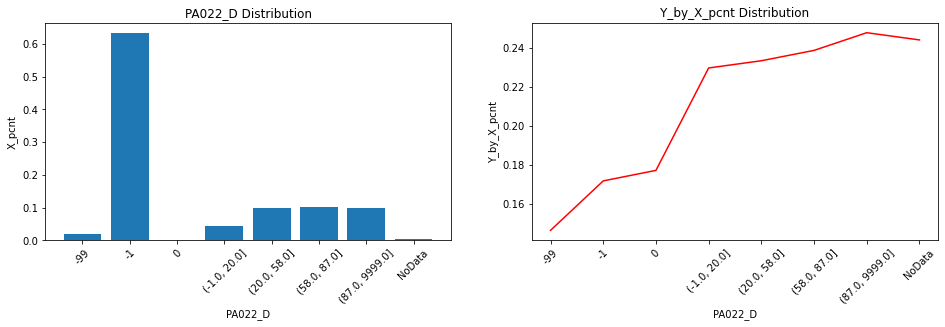

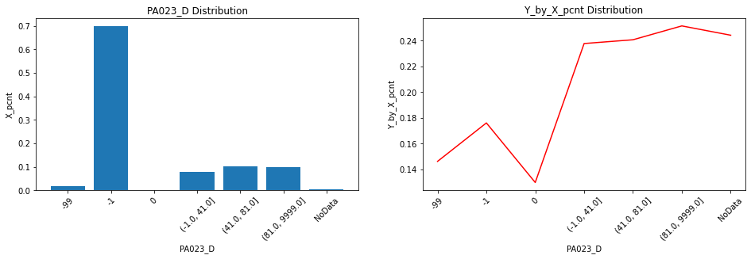

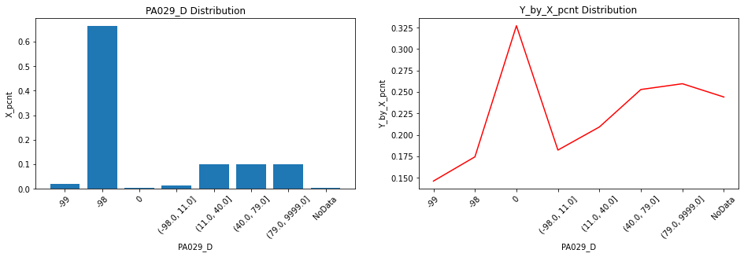

```python
for n in var_list_pa:
    plot_X_and_Y(n)
```

### Conclusion:

- the percentage of default increases as 'PA022' value increases. although '-1' has the most frequent count, the percentage of default is low compared to other values
- the percentage of default increases as 'PA023' value increases. although '-1' has the most frequent count, the percentage of default is not large compared to other values
- the probablilty of default increases as 'PA029' value increases. although '0' has low counts, the percentage of default is highest.

#### TD

Plot the distribution of each variable and the percentage of default distribution, for variables start with 'TD'

```python
var_list_td = ['TD001', 'TD005', 'TD006', 'TD009', 'TD010', 'TD014']
```

```python
#first check simple statistics
for value in var_list_td:
    print(train[value].describe())
```

```
count    56000.000000
mean         1.994446
std          1.811652
min          0.000000
25%          1.000000
50%          2.000000
75%          3.000000
max         20.000000
Name: TD001, dtype: float64
count    56000.000000
mean         3.598750
std          2.800152
min          0.000000
25%          2.000000
50%          3.000000
75%          5.000000
max         24.000000
Name: TD005, dtype: float64
count    56000.000000
mean         1.343661
std          1.402544
min          0.000000
25%          0.000000
50%          1.000000
75%          2.000000
max         18.000000
Name: TD006, dtype: float64
count    56000.000000
mean         5.411929
std          4.009127
min          0.000000
25%          3.000000
50%          4.000000
75%          7.000000
max         46.000000
Name: TD009, dtype: float64
count    56000.000000
mean         2.018018
std          1.956357
min          0.000000
25%          1.000000
50%          2.000000
75%          3.000000
max         35.000000
Name: TD010, dtype: float64
count    56000.000000
mean         2.602393
std          2.495521
min          0.000000
25%          1.000000
50%          2.000000
75%          4.000000
max         43.000000
Name: TD014, dtype: float64
```

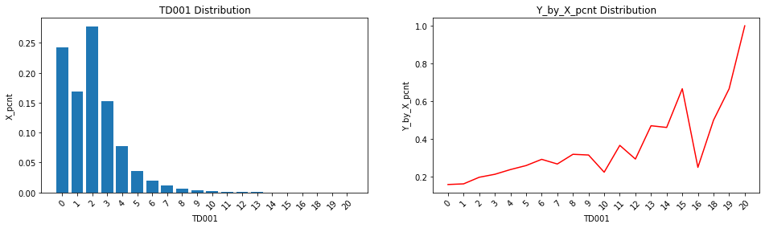

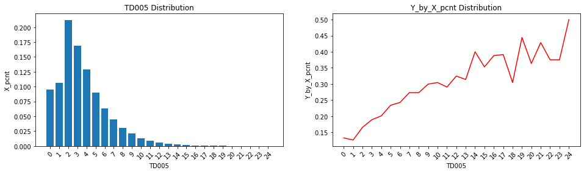

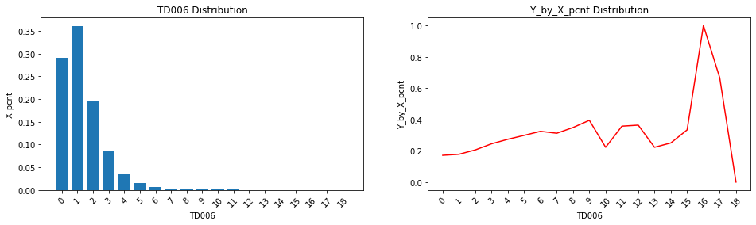

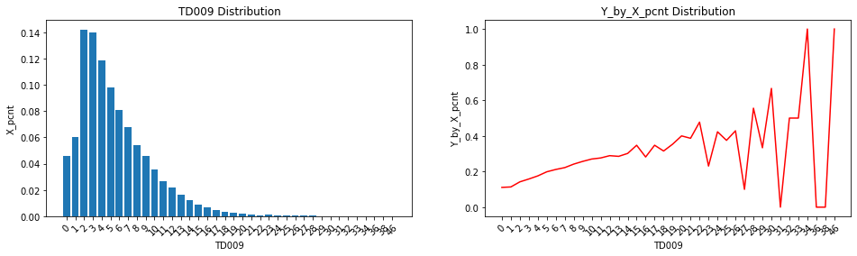

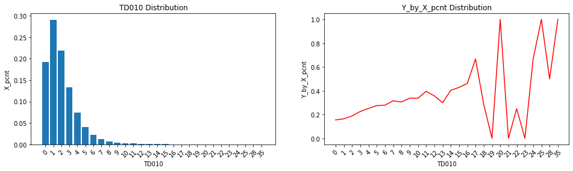

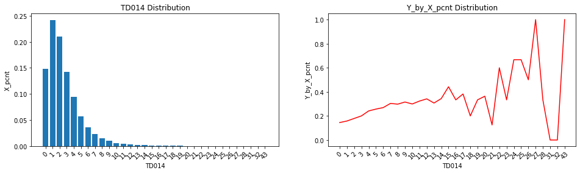

```python
for n in var_list_td:
    plot_X_and_Y(n)
```

### Thought process:

```python
#TD001
cut_bins = np.quantile(np.array(train['TD001']),np.arange(0,1.1,0.1), axis = 0).tolist()
cut_bins
```

```
[0.0, 0.0, 0.0, 1.0, 1.0, 2.0, 2.0, 3.0, 3.0, 4.0, 20.0]
```

```python
train['TD001_D'] = pd.cut(train['TD001'], bins = [-0.001,1,2,3,4,99], duplicates = 'drop')
```

```python
#TD005
cut_bins = np.quantile(np.array(train['TD005']),np.arange(0,1.1,0.1), axis = 0).tolist()
cut_bins
```

```
[0.0, 1.0, 1.0, 2.0, 2.0, 3.0, 4.0, 4.0, 5.0, 7.0, 24.0]
```

```python
train['TD005_D'] = pd.cut(train['TD005'], bins = [-0.001,1,2,3,4,6,7,99], duplicates = 'drop')
```

```python
#TD006
cut_bins = np.quantile(np.array(train['TD006']),np.arange(0,1.1,0.1), axis = 0).tolist()
cut_bins
```

```
[0.0, 0.0, 0.0, 1.0, 1.0, 1.0, 1.0, 2.0, 2.0, 3.0, 18.0]
```

```python
train['TD006_D'] = pd.cut(train['TD006'], bins = [-0.001,1,2,3,99], duplicates = 'drop')
```

```python
#TD009
cut_bins = np.quantile(np.array(train['TD009']),np.arange(0,1.1,0.1), axis = 0).tolist()
cut_bins
```

```
[0.0, 1.0, 2.0, 3.0, 4.0, 4.0, 5.0, 7.0, 8.0, 11.0, 46.0]
```

```python
train['TD009_D'] = pd.cut(train['TD009'], bins = [-0.001,1,2,3,4,5,7,8,11,99], duplicates = 'drop')
```

```python
#TD010
cut_bins = np.quantile(np.array(train['TD010']),np.arange(0,1.1,0.1), axis = 0).tolist()
cut_bins
```

```
[0.0, 0.0, 1.0, 1.0, 1.0, 2.0, 2.0, 2.0, 3.0, 4.0, 35.0]
```

```python
train['TD010_D'] = pd.cut(train['TD010'], bins = [-0.001,1,2,3,4,99], duplicates = 'drop')
```

```python
#TD014
cut_bins = np.quantile(np.array(train['TD014']),np.arange(0,1.1,0.1), axis = 0).tolist()
cut_bins
```

```
[0.0, 0.0, 1.0, 1.0, 2.0, 2.0, 2.0, 3.0, 4.0, 6.0, 43.0]
```

```python
train['TD014_D'] = pd.cut(train['TD014'], bins = [-0.001,1,2,3,4,6,99], duplicates = 'drop')
```

Plot the X_distribution_pcnt and Y_by_X_pcnt for binned variables

```python
var_list_td = ['TD001_D', 'TD005_D', 'TD006_D', 'TD009_D', 'TD010_D', 'TD014_D']
```

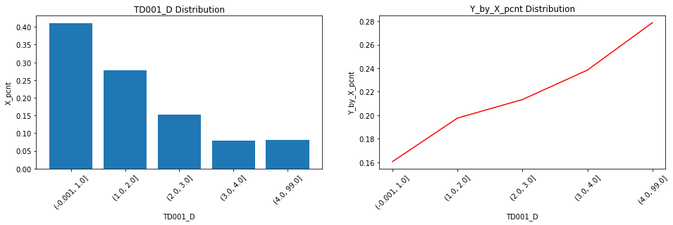

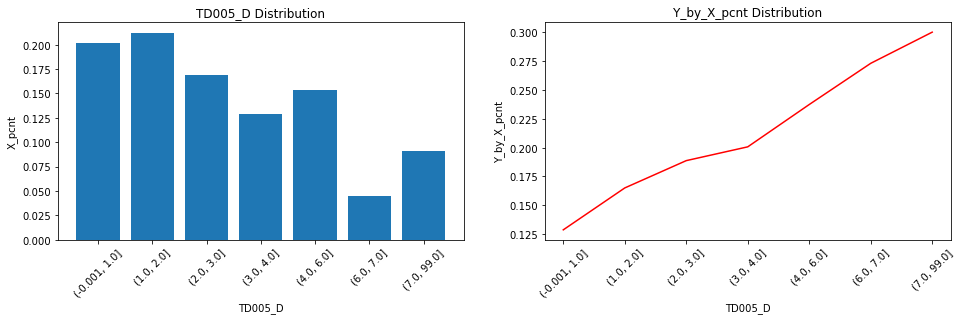

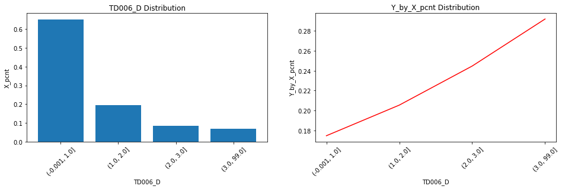

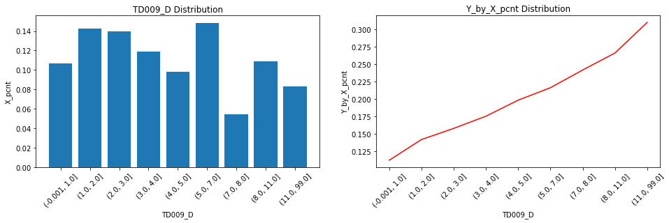

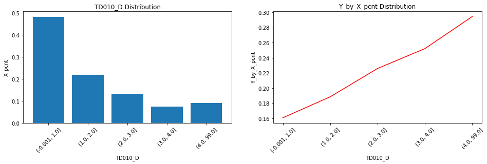

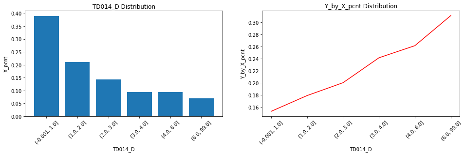

```python
for n in var_list_td:
    plot_X_and_Y(n)
```

### Conclusion:

- for all the variables above, the percentage of default increases as 'TDxxx' value increases

## Section 2. Feature Engineering

- Use Weight of Evidence encoding
- The goal of such transformation is to get the maximum difference among the binned categories relating to the target variable.
- It counts the number of responders and non-responders in each binned categories, then assigns a numeric value to each of the binned categories.

```python
import numpy as np
# create woe formula function for train data
def WOE_train(var):
    k = train[[var,'loan_default']].groupby(var)['loan_default'].agg(['count','sum']).reset_index()
    k.columns = [var,'Count','Default']
    k['Not_default'] = k['Count'] - k['Default']
    k['Default %'] = (k['Default'] / k['Default'].sum()*100).round(4)
    k['Not_default %'] = (k['Not_default'] / k['Not_default'].sum()*100).round(4)
    k[var+'_WOE'] = np.log(k['Not_default %'] / k['Default %']).round(4)
    k = k.sort_values(by=var+'_WOE')
    return(k)
```

```python
# take a look at variable 'TD014_D'
WOE_train('TD014_D')
```

|  | TD014_D | Count | Default | Not_default | Default % | Not_default % | TD014_D_WOE |
| --- | --- | --- | --- | --- | --- | --- | --- |
| 5 | (6.0, 99.0] | 3831 | 1193 | 2638 | 10.9540 | 5.8481 | -0.6276 |
| 4 | (4.0, 6.0] | 5253 | 1374 | 3879 | 12.6159 | 8.5992 | -0.3833 |
| 3 | (3.0, 4.0] | 5271 | 1273 | 3998 | 11.6886 | 8.8630 | -0.2767 |
| 2 | (2.0, 3.0] | 7991 | 1600 | 6391 | 14.6910 | 14.1679 | -0.0363 |
| 1 | (1.0, 2.0] | 11793 | 2110 | 9683 | 19.3738 | 21.4658 | 0.1025 |
| 0 | (-0.001, 1.0] | 21861 | 3341 | 18520 | 30.6767 | 41.0561 | 0.2914 |

```python
# create feature variable name list
feature = var_list_ap + var_list_cr + var_list_pa + var_list_td
```

```python
# create a list of all dataframes include woe value
dfs = [train]
for i in feature:
    dfs.append(WOE_train(i)[[i,i+'_WOE']])
```

```python
# merge all the data to a complete dataframe with feature transformation
from functools import reduce
train_woe = reduce(lambda df_left,df_right: pd.merge(df_left, df_right, how='outer'), dfs)
train_woe.head()
```

|  | Unnamed: 0.1 | Unnamed: 0 | id | AP001 | AP002 | AP003 | AP004 | AP005 | AP006 | AP007 | ... | CR019_WOE | PA022_D_WOE | PA023_D_WOE | PA029_D_WOE | TD001_D_WOE | TD005_D_WOE | TD006_D_WOE | TD009_D_WOE | TD010_D_WOE | TD014_D_WOE |
| --- | --- | --- | --- | --- | --- | --- | --- | --- | --- | --- | --- | --- | --- | --- | --- | --- | --- | --- | --- | --- | --- |
| 0 | 28419 | 28420 | 28420 | 26 | 1 | 3 | 12 | 2017/5/22 13:47 | ios | 5 | ... | 0.1331 | -0.2619 | -0.2721 | -0.0919 | -0.0198 | -0.254 | -0.5352 | -0.4065 | -0.5473 | -0.6276 |
| 1 | 34845 | 34846 | 34846 | 31 | 1 | 3 | 12 | 2017/7/2 9:08 | ios | 4 | ... | 0.1962 | -0.2619 | -0.2721 | -0.0919 | -0.0198 | -0.254 | -0.5352 | -0.4065 | -0.5473 | -0.6276 |
| 2 | 10696 | 10697 | 10697 | 34 | 1 | 3 | 12 | 2017/7/10 8:45 | ios | 5 | ... | -0.0454 | -0.2619 | 0.1219 | -0.0919 | -0.0198 | -0.254 | -0.5352 | -0.4065 | -0.5473 | -0.6276 |
| 3 | 49475 | 49476 | 49476 | 22 | 2 | 4 | 12 | 2017/5/12 10:20 | android | 2 | ... | -0.1222 | -0.2619 | 0.1219 | -0.0919 | -0.0198 | -0.254 | -0.5352 | -0.4065 | -0.5473 | -0.6276 |
| 4 | 76696 | 76697 | 76697 | 29 | 1 | 3 | 12 | 2017/4/12 15:57 | android | 2 | ... | -0.1222 | -0.2619 | -0.3301 | -0.0919 | -0.0198 | -0.254 | -0.5352 | -0.4065 | -0.5473 | -0.6276 |

5 rows × 116 columns

apply the same feature engineering to test dataset

```python
# first variable transformation from continuous to categorical

#AP001
test['AP001_D'] = pd.cut(test['AP001'], bins = [19.9, 24,26,27,28,30,32,34,37,43,99], duplicates = 'drop').astype('str')
#AP003
test['AP003_D'] = pd.cut(test['AP003'], bins = [0,1,3,7], duplicates = 'drop').astype('str')
#CR009
test['CR009_D'] = pd.cut(test['CR009'], bins = [-1,0,2499,6800,11500,17236,24263,34000,49982,82105,9999999], duplicates='drop').astype('str')
#PA022
test['PA022_D'] = pd.cut(test['PA022'], bins = [-99,-1.0,20,58,87,9999], duplicates = 'drop').cat.add_categories('NoData')
test['PA022_D'] = test['PA022_D'].fillna('NoData').astype(str)
test.loc[test['PA022']==-99, 'PA022_D'] = -99
test.loc[test['PA022']==-1, 'PA022_D'] = -1
test.loc[test['PA022']==0, 'PA022_D'] =0
#PA023
test['PA023_D'] = pd.cut(test['PA023'], bins = [-99,-1.0,41,81,9999], duplicates = 'drop').cat.add_categories('NoData')
test['PA023_D'] = test['PA023_D'].fillna('NoData').astype(str)
test.loc[test['PA023']==-99, 'PA023_D'] = -99
test.loc[test['PA023']==-1, 'PA023_D'] = -1
test.loc[test['PA023']==0, 'PA023_D'] =0
#PA029
test['PA029_D'] = pd.cut(test['PA029'], bins = [-99,-98,11.0,40,79,9999], duplicates = 'drop').cat.add_categories('NoData')
test['PA029_D'] = test['PA029_D'].fillna('NoData').astype(str)
test.loc[test['PA029']==-99, 'PA029_D'] = -99
test.loc[test['PA029']==-98, 'PA029_D'] = -98
test.loc[test['PA029']==0, 'PA029_D'] =0
#TD001
test['TD001_D'] = pd.cut(test['TD001'], bins = [-0.001,1,2,3,4,99], duplicates = 'drop').astype('str')
#TD005
test['TD005_D'] = pd.cut(test['TD005'], bins = [-0.001,1,2,3,4,6,7,99], duplicates = 'drop').astype('str')
#TD006
test['TD006_D'] = pd.cut(test['TD006'], bins = [-0.001,1,2,3,99], duplicates = 'drop').astype('str')
#TD009
test['TD009_D'] = pd.cut(test['TD009'], bins = [-0.001,1,2,3,4,5,7,8,11,99], duplicates = 'drop').astype('str')
#TD010
test['TD010_D'] = pd.cut(test['TD010'], bins = [-0.001,1,2,3,4,99], duplicates = 'drop').astype('str')
#TD014
test['TD014_D'] = pd.cut(test['TD014'], bins = [-0.001,1,2,3,4,6,99], duplicates = 'drop').astype('str')
```

```python
# define woe formula for test data
def WOE_test(var):
    k = test[[var,'loan_default']].groupby(var)['loan_default'].agg(['count','sum']).reset_index()
    k.columns = [var,'Count','Default']
    k['Not_default'] = k['Count'] - k['Default']
    k['Default %'] = (k['Default'] / k['Default'].sum()*100).round(4)
    k['Not_default %'] = (k['Not_default'] / k['Not_default'].sum()*100).round(4)
    k[var+'_WOE'] = np.log(k['Not_default %'] / k['Default %']).round(4)
    k = k.sort_values(by=var+'_WOE')
    return(k)
```

```python
# create a list of all dataframes include woe value
feature = var_list_ap + var_list_cr + var_list_pa + var_list_td
dfs = [test]
for i in feature:
    dfs.append(WOE_test(i)[[i,i+'_WOE']])
```

```python
# merge all the data to a complete dataframe with feature transformation
from functools import reduce
test_woe = reduce(lambda df_left,df_right: pd.merge(df_left, df_right, how='outer'), dfs)
test_woe.head()
```

|  | Unnamed: 0.1 | Unnamed: 0 | id | AP001 | AP002 | AP003 | AP004 | AP005 | AP006 | AP007 | ... | CR019_WOE | PA022_D_WOE | PA023_D_WOE | PA029_D_WOE | TD001_D_WOE | TD005_D_WOE | TD006_D_WOE | TD009_D_WOE | TD010_D_WOE | TD014_D_WOE |
| --- | --- | --- | --- | --- | --- | --- | --- | --- | --- | --- | --- | --- | --- | --- | --- | --- | --- | --- | --- | --- | --- |
| 0 | 7389 | 7390 | 7390 | 28 | 1 | 3 | 12 | 2017/6/20 13:36 | h5 | 5 | ... | -0.0044 | -0.1663 | -0.2151 | -0.3182 | -0.0306 | 0.2153 | -0.13 | 0.4171 | -0.0406 | 0.0643 |
| 1 | 69161 | 69162 | 69162 | 28 | 1 | 4 | 12 | 2017/7/7 14:40 | android | 5 | ... | 0.0392 | -0.1663 | -0.2151 | -0.3182 | -0.0306 | 0.2153 | -0.13 | 0.4171 | -0.0406 | 0.0643 |
| 2 | 51386 | 51387 | 51387 | 28 | 1 | 1 | 12 | 2017/5/21 18:46 | h5 | 2 | ... | 0.1901 | -0.2068 | -0.2151 | -0.3182 | -0.0306 | 0.2153 | -0.13 | 0.4171 | -0.0406 | 0.0643 |
| 3 | 20844 | 20845 | 20845 | 28 | 1 | 3 | 3 | 2017/6/5 22:01 | android | 3 | ... | 0.0392 | -0.2068 | -0.3256 | -0.3182 | -0.0306 | 0.2153 | -0.13 | 0.4171 | -0.0406 | 0.0643 |
| 4 | 22779 | 22780 | 22780 | 36 | 1 | 4 | 12 | 2017/7/5 10:54 | h5 | 5 | ... | 0.0392 | -0.1663 | -0.2151 | -0.1173 | -0.0306 | 0.2153 | -0.13 | 0.4171 | -0.0406 | 0.0643 |

5 rows × 116 columns

## Section 3. Modeling - Logistic Regression

#### Model 1

- Impute missing value with mean
- Features are continuous variables

```python
feature = ['AP001','AP003','AP008','CR009','CR015','CR019','PA022','PA023','PA029','TD001','TD005','TD006','TD009','TD010','TD014']
```

```python
X_train = train[feature].fillna(train[feature].mean())
X_test = test[feature].fillna(test[feature].mean())
Y_train = train['loan_default']
Y_test = test['loan_default']
```

```python
# fit logistic regression
from sklearn.linear_model import LogisticRegression
lgm1 = LogisticRegression(max_iter=1000)
lgm1.fit(X_train,Y_train)
```

```
LogisticRegression(max_iter=1000)
```

```python
# show the first ten prediction probability on test data
lgm1.predict_proba(X_test[0:10])
```

```
array([[0.76629721, 0.23370279],
       [0.74845123, 0.25154877],
       [0.88438997, 0.11561003],
       [0.76798591, 0.23201409],
       [0.83127609, 0.16872391],
       [0.92740616, 0.07259384],
       [0.89699628, 0.10300372],
       [0.53786125, 0.46213875],
       [0.82049127, 0.17950873],
       [0.72599487, 0.27400513]])
```

ROC metric

```python
import matplotlib.pyplot as plt
from sklearn.metrics import roc_curve,roc_auc_score

y_pred = lgm1.predict_proba(X_test)[:,1]
roc_auc_value1 = roc_auc_score(Y_test,y_pred)
roc_auc_value1
```

```
0.5913089639150437
```

```python
fpr1, tpr1, _ = roc_curve(Y_test, y_pred)
[fpr1,tpr1]
```

```
[array([0.00000000e+00, 0.00000000e+00, 1.54615266e-04, ...,
        9.99896923e-01, 9.99896923e-01, 1.00000000e+00]),
 array([0.00000000e+00, 2.17533174e-04, 2.17533174e-04, ...,
        9.99782467e-01, 1.00000000e+00, 1.00000000e+00])]
```

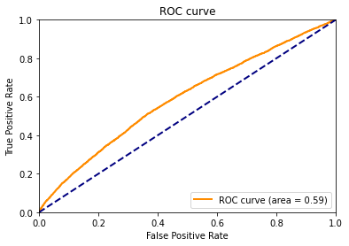

```python
import matplotlib.pyplot as plt
lw=2
plt.figure(figsize=(6,4))
plt.plot(fpr1,tpr1, color='darkorange',lw=lw,label='ROC curve (area = %0.2f)' %roc_auc_value1)
plt.plot([0,1],[0,1], color='navy',lw=lw,linestyle='--')
plt.xlim([0,1])
plt.ylim([0,1])
plt.xlabel('False Positive Rate')
plt.ylabel('True Positive Rate')
plt.title('ROC curve')
plt.legend(loc='lower right')
plt.show()
```

The plot shows the ROC curve of model 1, and model 1 has AUC = 0.59

#### Model 2:

- Bin continuous variables and missing values to categorical variables
- Apply feature engineering, use WOE score

```python
feature = var_list_ap + var_list_cr + var_list_pa + var_list_td
feature
```

```
['AP001_D',
 'AP003_D',
 'AP008',
 'CR009_D',
 'CR015',
 'CR019',
 'PA022_D',
 'PA023_D',
 'PA029_D',
 'TD001_D',
 'TD005_D',
 'TD006_D',
 'TD009_D',
 'TD010_D',
 'TD014_D']
```

```python
# Use woe scores for features in model
feature_woe = []
for var in feature:
    feature_woe.append(var+'_WOE')
```

```python
X_train = train_woe[feature_woe]
X_test = test_woe[feature_woe]
Y_train = train_woe['loan_default']
Y_test = test_woe['loan_default']
```

```python
# fit logistic regression
from sklearn.linear_model import LogisticRegression
lgm2 = LogisticRegression(max_iter=1000)
lgm2.fit(X_train,Y_train)
```

```
LogisticRegression(max_iter=1000)
```

```python
# show the first ten prediction probability on test data
lgm2.predict_proba(X_test[0:10])
```

```
array([[0.8415808 , 0.1584192 ],
       [0.90379095, 0.09620905],
       [0.77122354, 0.22877646],
       [0.85580975, 0.14419025],
       [0.91993658, 0.08006342],
       [0.77624197, 0.22375803],
       [0.86757393, 0.13242607],
       [0.83985948, 0.16014052],
       [0.81036012, 0.18963988],
       [0.84596317, 0.15403683]])
```

ROC metric

```python
import matplotlib.pyplot as plt
from sklearn.metrics import roc_curve,roc_auc_score

y_pred = lgm2.predict_proba(X_test)[:,1]
roc_auc_value2 = roc_auc_score(Y_test,y_pred)
roc_auc_value2
```

```
0.6499625300986009
```

```python
fpr2, tpr2, _ = roc_curve(Y_test, y_pred)
[fpr2,tpr2]
```

```
[array([0.00000000e+00, 0.00000000e+00, 5.15384219e-05, ...,
        9.98866155e-01, 9.98969232e-01, 1.00000000e+00]),
 array([0.00000000e+00, 2.17533174e-04, 2.17533174e-04, ...,
        1.00000000e+00, 1.00000000e+00, 1.00000000e+00])]
```

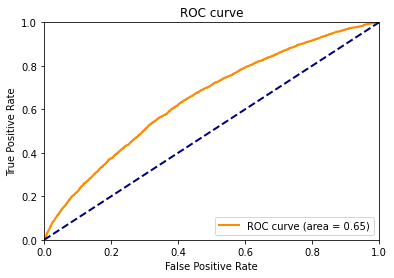

```python
import matplotlib.pyplot as plt
lw=2
plt.figure(figsize=(6,4))
plt.plot(fpr2,tpr2, color='darkorange',lw=lw,label='ROC curve (area = %0.2f)' %roc_auc_value2)
plt.plot([0,1],[0,1], color='navy',lw=lw,linestyle='--')
plt.xlim([0,1])
plt.ylim([0,1])
plt.xlabel('False Positive Rate')
plt.ylabel('True Positive Rate')
plt.title('ROC curve')
plt.legend(loc='lower right')
plt.show()
```

The plot shows the ROC curve of model 2, and model 2 has AUC = 0.65

**Compare the two ROC curve for model 1 and model 2**

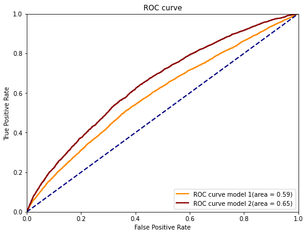

```python
import matplotlib.pyplot as plt
lw=2
plt.figure(figsize=(8,6))
plt.plot(fpr1,tpr1, color='darkorange',lw=lw,label='ROC curve model 1(area = %0.2f)' %roc_auc_value1)
plt.plot(fpr2,tpr2, color='darkred',lw=lw,label='ROC curve model 2(area = %0.2f)' %roc_auc_value2)
plt.plot([0,1],[0,1], color='navy',lw=lw,linestyle='--')
plt.xlim([0,1])
plt.ylim([0,1])
plt.xlabel('False Positive Rate')
plt.ylabel('True Positive Rate')
plt.title('ROC curve')
plt.legend(loc='lower right')
plt.show()
```

#### Conclusion:

- The higher AUC score, the better the performance of the model at predicting 0 classes as 0 and 1 classes as 1.
- For this case, model 2 has a better performance at predicting default from non-default

## Section 4. Summary & limitation

For this project,

- I did exploratory data analysis to understand the variables, the relationship between variables and target variable
- I did feature engineering, perform weight of evidence encoding
- I created two models, one without feature engineering, and one with feature engineering. Compare the results and performance of the two models

Limitation:

- When performing variable transformation for training and testing data, I manually create the same variable bins for testing data based on the training data. Luckily this time, all test variables fall within the bin groups without exception. I did not consider this is the best way to perform variable transformation and would research and study more to come up with better solutions.